# Data Camp / Manipulating Time Series Data in R: Case Studies - Chapter 1

Initialize and load the data

```r
library(readr)
library(dplyr)
library(xts)
library(zoo)
```

Chapter 1 of [Data Camp - Manipulating Time Series Data in R: Case Studies](https://www.datacamp.com/courses/manipulating-time-series-data-in-r-case-studies)

## Logan Airport - Reverse Engineer

### Get data

1. Go To [Beureau of Transportation Statistics](https://www.transtats.bts.gov/)
2. Search on *on time delay*
3. Select *Airlin On-Tim Statistics and Delay Causes* https://www.transtats.bts.gov/OT_Delay/OT_DelayCause1.asp
4. Select the date range (2010/01 - 2015/12) an download the data.
5. Unzip the data to get the .csv

```r
read_csv('data/324015381_32017_2459_airline_delay_causes.csv') -> raw_data
```

### Prep the data

What’s the data look like and what do we want?

```r
glimpse(raw_data)
```

```
## Observations: 871
## Variables: 22
## $ year                <int> 2010, 2010, 2010, 2010, 2010, 2010, 2010, ...
## $ month               <int> 1, 1, 1, 1, 1, 1, 1, 1, 1, 1, 1, 1, 1, 1, ...
## $ carrier             <chr> "9E", "AA", "AS", "B6", "CO", "DL", "F9", ...
## $ carrier_name        <chr> "Pinnacle Airlines Inc.", "American Airlin...
## $ airport             <chr> "BOS", "BOS", "BOS", "BOS", "BOS", "BOS", ...
## $ airport_name        <chr> "Boston, MA: Logan International", "Boston...
## $ arr_flights         <dbl> 87, 942, 55, 1756, 325, 1261, 26, 544, 782...
## $ arr_del15           <dbl> 16, 236, 13, 442, 76, 258, 19, 133, 169, 8...
## $ carrier_ct          <dbl> 1.97, 72.95, 0.33, 94.53, 28.14, 58.36, 1....
## $ weather_ct          <dbl> 0.84, 13.76, 0.00, 1.99, 1.00, 18.11, 0.22...
## $ nas_ct              <dbl> 9.19, 100.25, 12.67, 160.94, 34.99, 140.82...
## $ security_ct         <dbl> 0.00, 0.71, 0.00, 0.03, 4.49, 0.00, 0.00, ...
## $ late_aircraft_ct    <dbl> 4.01, 48.33, 0.00, 184.50, 7.38, 40.71, 8....
## $ arr_cancelled       <dbl> 2, 29, 0, 31, 4, 49, 0, 7, 30, 17, 10, 85,...
## $ arr_diverted        <dbl> 1, 1, 0, 2, 0, 0, 0, 2, 1, 0, 2, 0, 0, 0, ...
## $ arr_delay           <dbl> 1115, 13852, 602, 31094, 3733, 13501, 1357...
## $ carrier_delay       <dbl> 295, 5325, 6, 6570, 1100, 3014, 54, 1461, ...
## $ weather_delay       <dbl> 78, 561, 0, 331, 80, 1832, 15, 4, 119, 102...
## $ nas_delay           <dbl> 582, 4350, 596, 9116, 1653, 5737, 826, 337...
## $ security_delay      <dbl> 0, 34, 0, 2, 487, 0, 0, 0, 450, 0, 0, 22, ...
## $ late_aircraft_delay <dbl> 160, 3582, 0, 15075, 413, 2918, 462, 1803,...
## $ X22                 <chr> NA, NA, NA, NA, NA, NA, NA, NA, NA, NA, NA...
```

```r
head(raw_data, n=2)
```

```
## # A tibble: 2 x 22
##    year month carrier           carrier_name airport
##   <int> <int>   <chr>                  <chr>   <chr>
## 1  2010     1      9E Pinnacle Airlines Inc.     BOS
## 2  2010     1      AA American Airlines Inc.     BOS
## # ... with 17 more variables: airport_name <chr>, arr_flights <dbl>,
## #   arr_del15 <dbl>, carrier_ct <dbl>, weather_ct <dbl>, nas_ct <dbl>,
## #   security_ct <dbl>, late_aircraft_ct <dbl>, arr_cancelled <dbl>,
## #   arr_diverted <dbl>, arr_delay <dbl>, carrier_delay <dbl>,
## #   weather_delay <dbl>, nas_delay <dbl>, security_delay <dbl>,
## #   late_aircraft_delay <dbl>, X22 <chr>
```

### Get the same data

There are some low hangin fruits. For instance, we are interested only in monthly data for “ALL” carriers, so we can summarize the data. Next, the date is represented as Year and Month separately so we can combine these into a single value. Also, We know the data is for Logan in boston so we can drop the airport and airport_name fields, not required. Finally, what the hell is X22? No idea so let’s loose it.

```r
mutate(raw_data, date=sprintf("%04d-%02d-01", as.numeric(year), as.numeric(month))) %>%
  select(-year, -month, -carrier, -carrier_name, -airport, -airport_name, -X22) %>%
  (function(.data) {aggregate(. ~ date, .data, sum)}) %>%
  select(total_flights=arr_flights, delay_flights=arr_del15, cancel_flights=arr_cancelled,
         divert_fligths=arr_diverted, date) -> flights

glimpse(flights)
```

```
## Observations: 72
## Variables: 5
## $ total_flights  <dbl> 8912, 8418, 9637, 9363, 9360, 9502, 9992, 10173...
## $ delay_flights  <dbl> 1989, 1918, 2720, 1312, 1569, 1955, 2256, 2108,...
## $ cancel_flights <dbl> 279, 785, 242, 58, 102, 157, 222, 138, 144, 131...
## $ divert_fligths <dbl> 9, 23, 32, 7, 8, 5, 10, 20, 6, 9, 2, 6, 11, 7, ...
## $ date           <chr> "2010-01-01", "2010-02-01", "2010-03-01", "2010...
```

The course dataset has 5 columns:

- total_flights
- delay_flights
- cancel_flights
- divert_flights
- date

By comparing the vlaues of the first few records we find that the above are:

- arr_flights
- arr_del15
- arr_canceled
- arr_diverted

## Analysis

Now to the analysis from the course

### Getting to know you

To start get to know your data… So we did above but let’s stay true to the course.

What’s the **str**ucture of the data?  
What’s the data look like?  
We need the date, what’s the dates format?

```r
str(flights)
```

```
## 'data.frame':    72 obs. of  5 variables:
##  $ total_flights : num  8912 8418 9637 9363 9360 ...
##  $ delay_flights : num  1989 1918 2720 1312 1569 ...
##  $ cancel_flights: num  279 785 242 58 102 157 222 138 144 131 ...
##  $ divert_fligths: num  9 23 32 7 8 5 10 20 6 9 ...
##  $ date          : chr  "2010-01-01" "2010-02-01" "2010-03-01" "2010-04-01" ...
```

```r
head(flights, n=5)
```

```
##   total_flights delay_flights cancel_flights divert_fligths       date
## 1          8912          1989            279              9 2010-01-01
## 2          8418          1918            785             23 2010-02-01
## 3          9637          2720            242             32 2010-03-01
## 4          9363          1312             58              7 2010-04-01
## 5          9360          1569            102              8 2010-05-01
```

```r
class(flights$date)
```

```
## [1] "character"
```

### Fixing the data

Essential in data analysis, bad in relationships

The date needs to be converted to a Time structure and the xts structure created.

```r
flights$date = as.Date(flights$date)
flights_xts = xts(flights[,-5], order.by=flights$date)
class(flights_xts)
```

```
## [1] "xts" "zoo"
```

```r
head(flights_xts, n=5)
```

```
##            total_flights delay_flights cancel_flights divert_fligths
## 2010-01-01          8912          1989            279              9
## 2010-02-01          8418          1918            785             23
## 2010-03-01          9637          2720            242             32
## 2010-04-01          9363          1312             58              7
## 2010-05-01          9360          1569            102              8
```

### Qaulities of the data

- Periodicity
- Scope
- Comprehensiveness.

Use the `periodicity()` function in the **xts** library to get the periodicity of the data.  
Use the `ndays()` or `nmonths()`, `nyears()`, etc. To get the number of periods in the data.  
Remember that an **xts** object can be sub-setted by dates and partial dates using the ISO format.

```r
periodicity(flights_xts)
```

```
## Monthly periodicity from 2010-01-01 to 2015-12-01
```

```r
ndays(flights_xts)
```

```
## [1] 72
```

```r
nmonths(flights_xts)
```

```
## [1] 72
```

```r
flights_xts['201406']
```

```
##            total_flights delay_flights cancel_flights divert_fligths
## 2014-06-01          9662          2279            141              6
```

### Plotting data

**xts** offers a simple way to plot an xts dataset, `plot.xts()`. This takes a single argument, an xts object, and uses the date indes as the x axis.

For more complex charts you can use the `plot.zoo()` function. This provides for plotting multple columns of data in different ways, single panel or multiple panels and provides control over indexes.

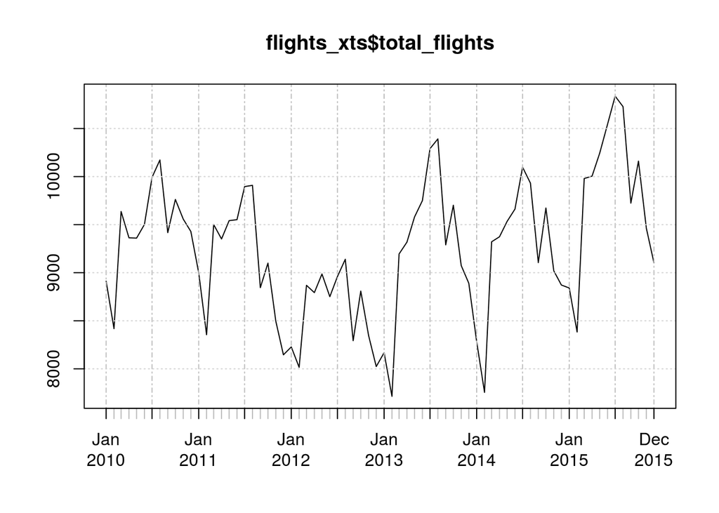

```r
labels = c("Total" , "Delay",  "Cancel", "Divert")
lty = c(1,2,3,4)

plot.xts(flights_xts$total_flights)
```

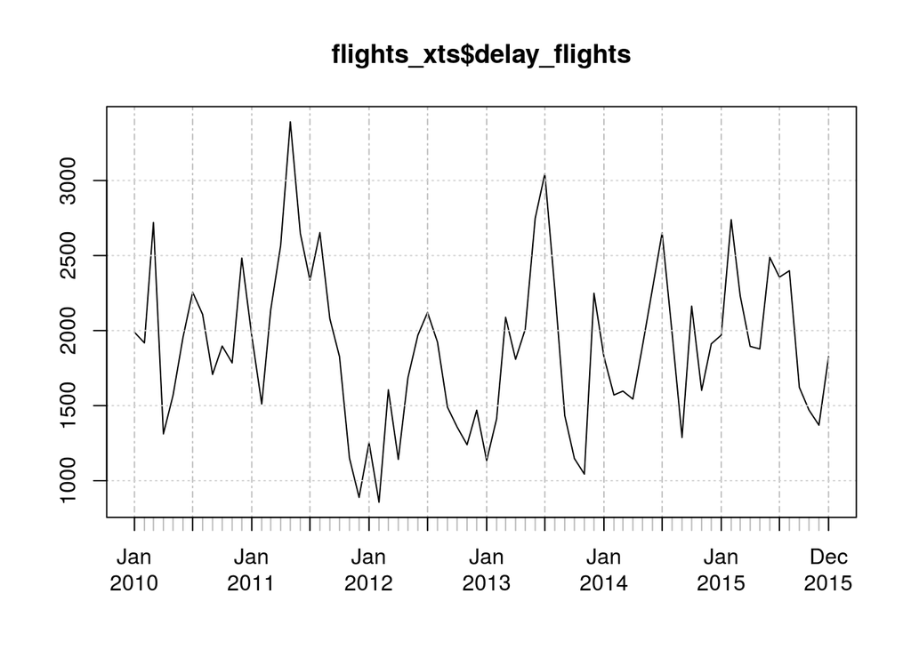

```r
# Use plot.xts() to view monthly delayed flights into BOS over time
plot.xts(flights_xts$delay_flights)
```

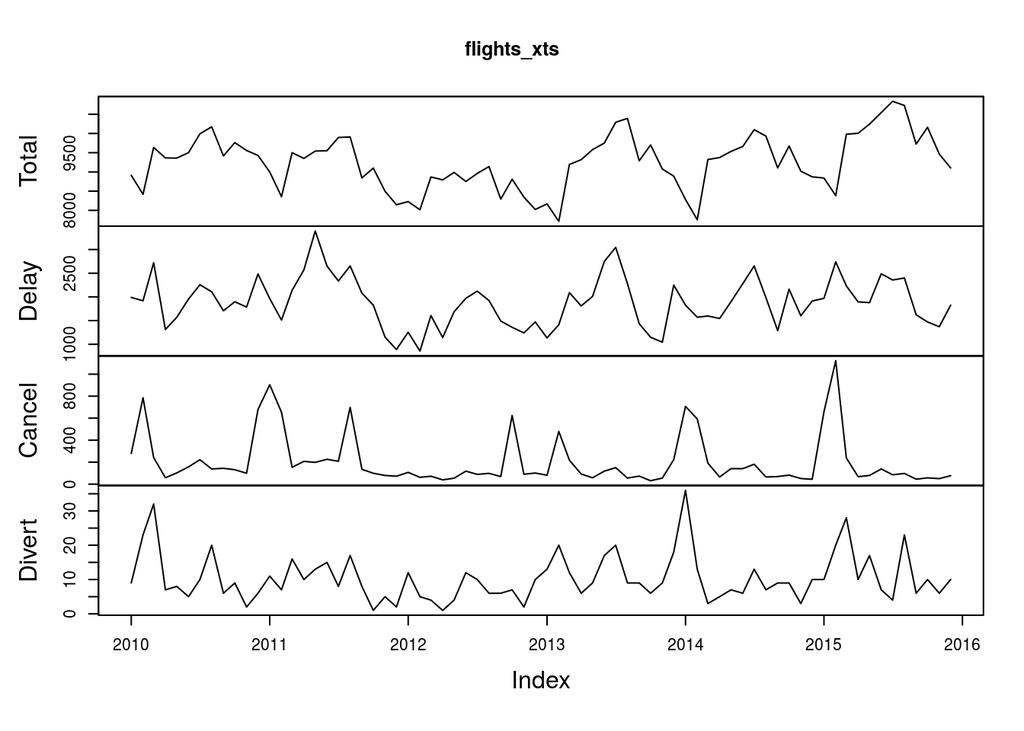

```r
# Use plot.zoo() to view all four columns of data in their own panels
plot.zoo(flights_xts, plot.type = "multiple", ylab = labels)
```

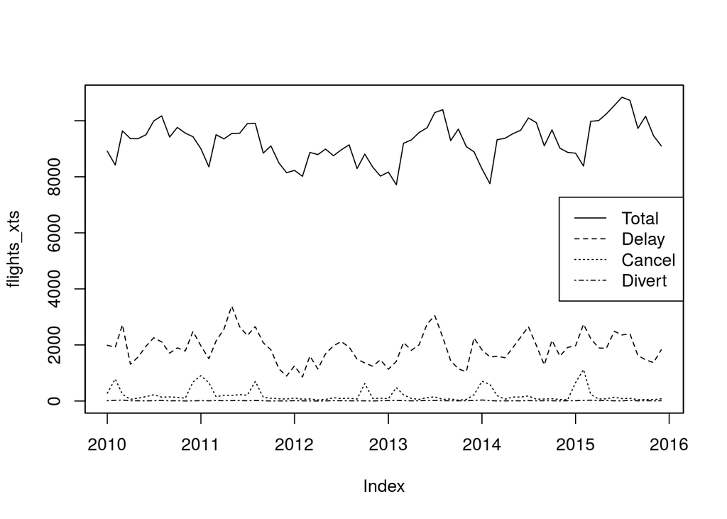

```r
# Use plot.zoo() to view all four columns of data in one panel
plot.zoo(flights_xts, plot.type = "single", lty = lty)
legend("right", lty = lty, legend = labels)
```

### Creating new variables

Let’s calculate the % of delays, missed, etc.

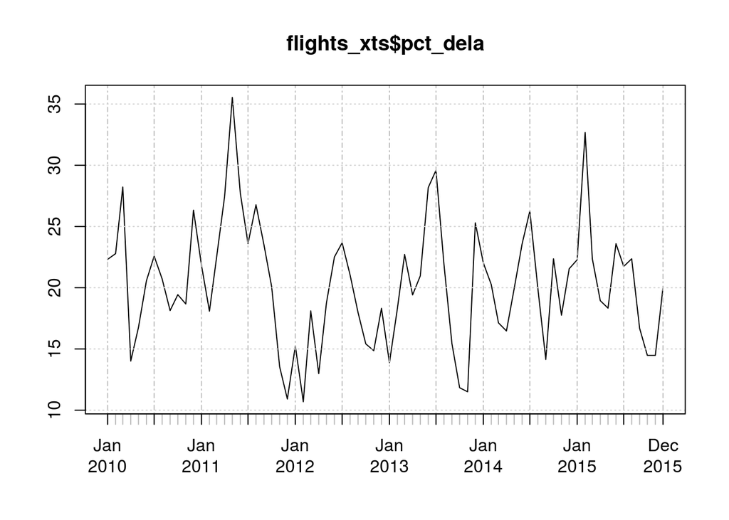

```r
# Calculate percentage of flights delayed each month: pct_delay
flights_xts$pct_delay <- ((flights_xts$delay_flights) / flights_xts$total_flights) * 100

# Use plot.xts() to view pct_delay over time
plot.xts(flights_xts$pct_dela)
```

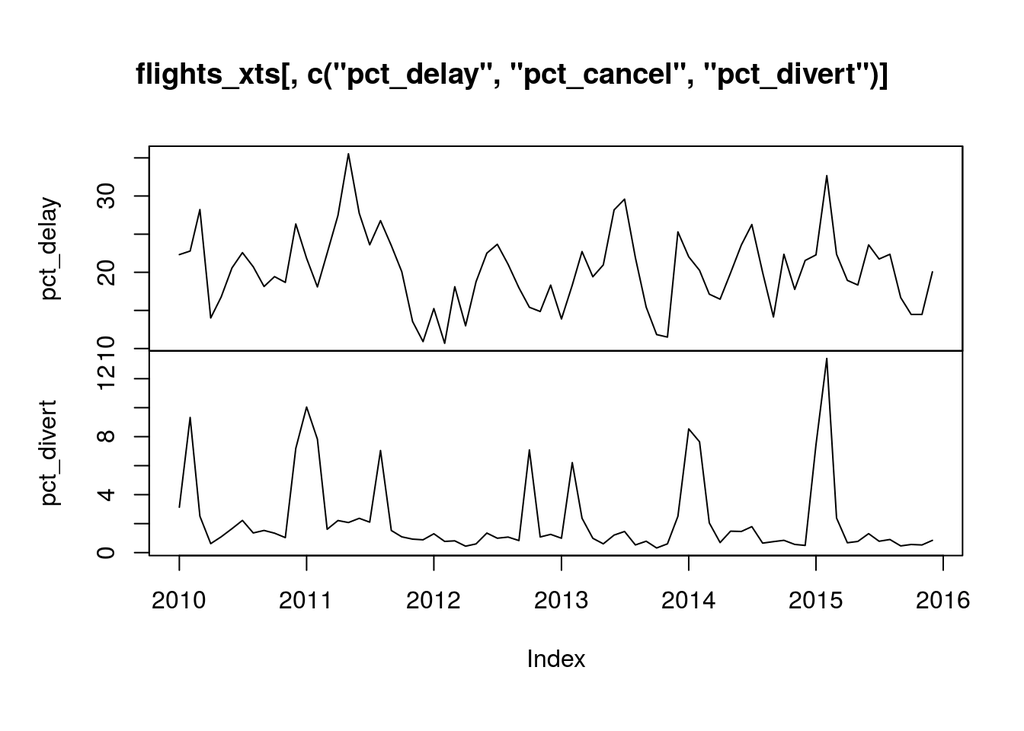

```r
# Calculate percentage of flights cancelled each month: pct_cancel
flights_xts$pct_cancel <- ((flights_xts$cancel_flights) / flights_xts$total_flights) * 100

# Calculate percentage of flights diverted each month: pct_divert
flights_xts$pct_divert <- ((flights_xts$divert_flights) / flights_xts$total_flights) * 100

# Use plot.zoo() to view all three trends over time
plot.zoo(x = flights_xts[ , c("pct_delay", "pct_cancel", "pct_divert")])
```

### Saving your data

There are several ways to save data from an xts object. The preferred method is to save it as an RDS file with the `saveRDS()` function. This preserves the full object. In cases where you need to exchange the data with someone who may not be using R, you can use the `write.zoo()` function to write the data as a .csv file. However, if you use this method and then read the data back in with `read.zoo()`, you will need to convert it back to an **xts** object with `as.xts()`.

```r
# Save your xts object to rds file using saveRDS
saveRDS(object = flights_xts, file = "flights_xts.rds")

# Read your flights_xts data from the rds file
flights_xts2 <- readRDS("flights_xts.rds")

# Check the class of your new flights_xts2 object
class(flights_xts2)
```

```
## [1] "xts" "zoo"
```

```r
# Examine the first five rows of your new flights_xts2 object
head(flights_xts2)
```

```
##            total_flights delay_flights cancel_flights divert_fligths
## 2010-01-01          8912          1989            279              9
## 2010-02-01          8418          1918            785             23
## 2010-03-01          9637          2720            242             32
## 2010-04-01          9363          1312             58              7
## 2010-05-01          9360          1569            102              8
## 2010-06-01          9502          1955            157              5
##            pct_delay pct_divert
## 2010-01-01  22.31822  3.1306104
## 2010-02-01  22.78451  9.3252554
## 2010-03-01  28.22455  2.5111549
## 2010-04-01  14.01260  0.6194596
## 2010-05-01  16.76282  1.0897436
## 2010-06-01  20.57462  1.6522837
```

Now to .csv

```r
# Export your xts object to a csv file using write.zoo
write.zoo(flights_xts, file = "flights_xts.csv", sep = ",")

# Open your saved object using read.zoo
flights2 <- read.zoo("flights_xts.csv", sep = ",", FUN = as.Date, header = TRUE, index.column = 1)

# Encode your new object back into xts
flights_xts2 <- as.xts(flights2)

# Examine the first five rows of your new flights_xts2 object
head(flights_xts2, n=5)
```

```
##            total_flights delay_flights cancel_flights divert_fligths
## 2010-01-01          8912          1989            279              9
## 2010-02-01          8418          1918            785             23
## 2010-03-01          9637          2720            242             32
## 2010-04-01          9363          1312             58              7
## 2010-05-01          9360          1569            102              8
##            pct_delay pct_divert
## 2010-01-01  22.31822  3.1306104
## 2010-02-01  22.78451  9.3252554
## 2010-03-01  28.22455  2.5111549
## 2010-04-01  14.01260  0.6194596
## 2010-05-01  16.76282  1.0897436
```